# Analyse des Correspondances

Jeu de données mite2

Ce jeu de données contient 70 lignes et 35 colonnes.

### 1. Observation d’individus extrêmes

La détection des individus extrêmes ne s’applique pas à l’AFC.

### 2. Distribution de l’inertie

L’inertie des axes factoriels indique d’une part si les variables sont structurées et suggère d’autre part le nombre judicieux de composantes principales à étudier.

Les 2 premiers axes de l’ analyse expriment **42.88%** de l’inertie totale du jeu de données ; cela signifie que 42.88% de la variabilité totale du nuage des lignes (ou des colonnes) est représentée dans ce plan. C’est un pourcentage relativement moyen, et le premier plan représente donc seulement une part de la variabilité contenue dans l’ensemble du jeu de données actif. Cette valeur est nettement supérieure à la valeur référence de **15.78%**, la variabilité expliquée par ce plan est donc hautement significative (cette intertie de référence est le quantile 0.95-quantile de la distribution des pourcentages d’inertie obtenue en simulant 3287 jeux de données aléatoires de dimensions comparables sur la base d’une distribution uniforme).

Du fait de ces observations, il serait alors probablement nécessaire de considérer également les dimensions supérieures ou égales à la troisième dans l’analyse.

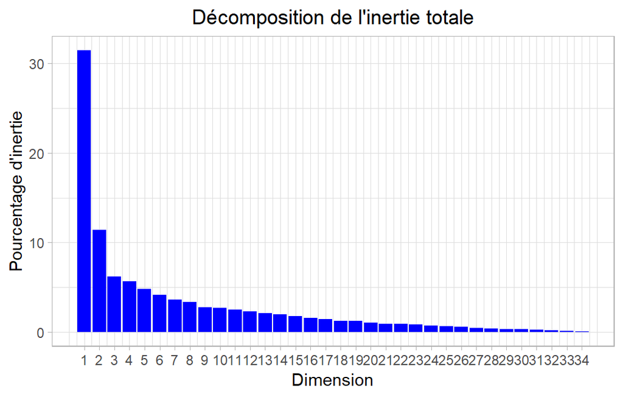

**Figure 2 - Décomposition de l’inertie totale**

Une estimation du nombre pertinent d’axes à interpréter suggère de restreindre l’analyse à la description des 2 premiers axes. Ces composantes révèlent un taux d’inertie supérieur à celle du quantile 0.95-quantile de distributions aléatoires (42.88% contre 15.78%). Cette observation suggère que seuls ces axes sont porteurs d’une véritable information. En conséquence, la description de l’analyse sera restreinte à ces seuls axes.

### 3. Description du plan 1:2

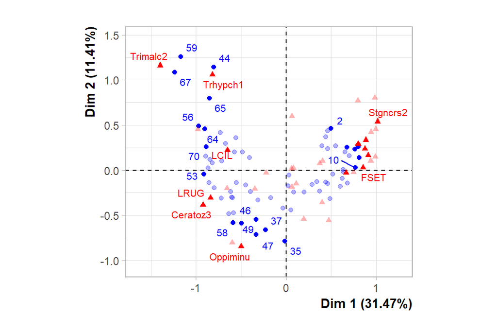

**Figure 3.1 - Graphe superposé (AFC)** *Les lignes libellées sont celles ayant la plus grande contribution à la construction du plan.* *Les colonnes libellées sont celles les mieux représentées sur le plan.*

La **dimension 1** oppose des facteurs tels que *10*, *8*, *6*, *14* et *20* (à droite du graphe, caractérisés par une coordonnée fortement positive sur l’axe) à des facteurs comme *64*, *56*, *70*, *65*, *67*, *53*, *59*, *47*, *46* et *49* (à gauche du graphe, caractérisés par une coordonnée fortement négative sur l’axe).

Le groupe auquel les facteurs *10*, *8*, *6*, *14* et *20* appartiennent (caractérisés par une coordonnée positive sur l’axe) partage :

- une forte fréquence des modalités telles que *TVEL*, *FSET*, *HMIN2*, *PHTH*, *Galumna1*, *Stgncrs2*, *Oribatl1*, *RARD*, *MEGR* et *SSTR* (du plus commun au plus rare).
- une faible fréquence des modalités *LRUG*, *Ceratoz3*, *LCIL*, *Oppiminu*, *Trimalc2*, *NCOR*, *TVIE* et *PLAG2* (du plus rare au plus commun).

Le groupe auquel les facteurs *64*, *56*, *70*, *65*, *67*, *53* et *59* appartiennent (caractérisés par une coordonnées négative sur l’axe) partage :

- une forte fréquence des modalités *Trimalc2*, *TVIE*, *Trhypch1* et *LCIL* (du plus commun au plus rare).
- une faible fréquence des modalités telles que *ONOV*, *HMIN*, *Eupelops*, *FSET*, *SUCT*, *MEGR*, *TVEL*, *HMIN2*, *PHTH* et *Galumna1* (du plus rare au plus commun).

Le groupe auquel les facteurs *47*, *46*, *49*, *37*, *58* et *35* appartiennent (caractérisés par une coordonnées négative sur l’axe) partage :

- une forte fréquence des modalités *Oppiminu*, *LRUG*, *PLAG2*, *NCOR* et *Ceratoz3* (du plus commun au plus rare).
- une faible fréquence des modalités telles que *Brachy*, *Oribatl1*, *Trimalc2*, *HMIN2*, *TVEL*, *PHTH*, *Galumna1*, *Stgncrs2*, *FSET* et *RARD* (du plus rare au plus commun).

### 4. Classification

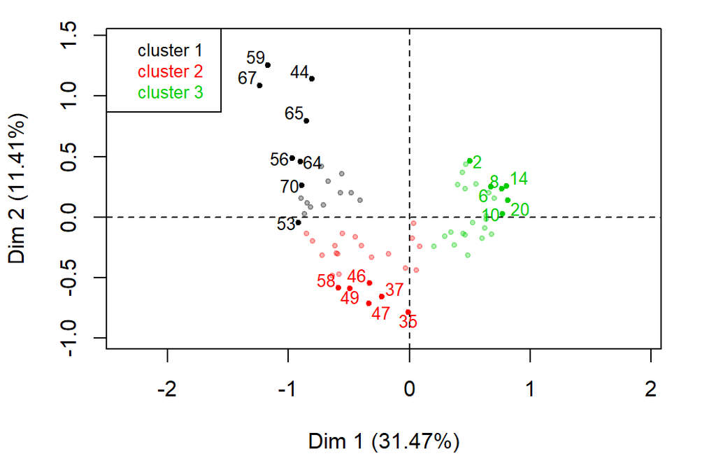

**Figure 4 - Classification Ascendante Hiérachique des lignes.** *La classification réalisée sur les lignes fait apparaître 3 clusters.*

La classe 1 est composée de lignes telles que *67*, *59*, *56*, *53*, *64*, *70*, *65* et *44*. Ce groupe est caractérisé par :

- une forte fréquence des modalités *Trimalc2*, *Trhypch1*, *LCIL*, *TVIE* et *LRUG* (du plus commun au plus rare).
- une faible fréquence des modalités *TVEL*, *HMIN*, *FSET*, *HMIN2*, *Oribatl1*, *Galumna1*, *RARD*, *PHTH*, *Eupelops* et *Stgncrs2* (du plus rare au plus commun).

La classe 2 est composée de lignes telles que *58*, *49*, *47*, *46*, *37* et *35*. Ce groupe est caractérisé par :

- une forte fréquence des modalités *LRUG*, *Oppiminu*, *PLAG2*, *Ceratoz3*, *LCIL* et *NCOR* (du plus commun au plus rare).
- une faible fréquence des modalités telles que *Trimalc2*, *RARD*, *PHTH*, *Stgncrs2*, *Oribatl1*, *Galumna1*, *HMIN2*, *TVEL*, *FSET* et *Trhypch1* (du plus rare au plus commun).

La classe 3 est composée de lignes telles que *2*, *6*, *8*, *10*, *14* et *20*. Ce groupe est caractérisé par :

- une forte fréquence des modalités telles que *TVEL*, *RARD*, *PHTH*, *FSET*, *Oribatl1*, *HMIN2*, *Galumna1*, *Stgncrs2*, *SSTR* et *SLAT* (du plus commun au plus rare).
- une faible fréquence des modalités telles que *LRUG*, *LCIL*, *Trimalc2*, *Ceratoz3*, *Oppiminu*, *NCOR*, *TVIE*, *Trhypch1*, *PLAG2* et *Ceratoz1* (du plus rare au plus commun).

## Annexes

```r
res.hcpc$desc.var
```

```
$`1`
           Intern %   glob % Intern freq Glob freq       p.value
Trimalc2  7.6533228 1.684611  30.1057296   30.79888 1.910615e-19
Trhypch1  7.8114956 2.552116  30.7279308   46.65902 5.096830e-10
LCIL     16.3559096 9.153225  64.3389285  167.34372 2.797950e-07
TVIE      4.1066460 1.480909  16.1542347   27.07469 3.893520e-05
LRUG     10.6268722 6.376518  41.8027237  116.57861 6.725189e-04
Stgncrs2  0.0000000 1.133927   0.0000000   20.73101 1.205096e-02
Eupelops  0.1762083 1.386434   0.6931472   25.34747 4.499897e-03
PHTH      0.2792835 1.900866   1.0986123   34.75255 4.135705e-03
RARD      0.0000000 1.610370   0.0000000   29.44157 1.681484e-03
Galumna1  0.0000000 1.623268   0.0000000   29.67738 1.320181e-03
Oribatl1  0.4554918 2.395998   1.7917595   43.80481 5.504360e-04
HMIN2     0.0000000 2.248903   0.0000000   41.11555 8.643056e-05
FSET      0.0000000 2.399853   0.0000000   43.87528 4.100872e-05
HMIN      0.1762083 3.599791   0.6931472   65.81312 1.657110e-07
TVEL      0.3524166 5.601964   1.3862944  102.41783 5.253438e-10
            v.test
Trimalc2  9.018282
Trhypch1  6.216094
LCIL      5.136572
TVIE      4.113709
LRUG      3.400544
Stgncrs2 -2.510649
Eupelops -2.840811
PHTH     -2.867621
RARD     -3.141389
Galumna1 -3.211556
Oribatl1 -3.454930
HMIN2    -3.925832
FSET     -4.101722
HMIN     -5.234189
TVEL     -6.211341

$`2`
           Intern %    glob % Intern freq Glob freq       p.value
LRUG     11.8583102 6.3765182  68.0143094  116.57861 1.179017e-09
Oppiminu  4.4711203 1.8984636  25.6444770   34.70863 2.095374e-06
PLAG2     2.9189752 1.3070781  16.7420214   23.89664 7.439861e-04
Ceratoz3  3.7797750 2.0534028  21.6792094   37.54131 3.495356e-03
```

[output cut: 69 more lines]

```
HMIN       2.114048
HPAV      -2.149873
Ceratoz1  -2.676625
PLAG2     -3.887191
Trhypch1  -4.206670
TVIE      -4.284633
NCOR      -4.692708
Oppiminu  -5.228899
Ceratoz3  -5.551477
Trimalc2  -5.874301
LCIL      -7.249846
LRUG     -10.272357

attr(,"class")
[1] "descfreq" "list"
```

**Figure 5 - Liste des variables caractéristiques des clusters de la classification.**